# Marketing Mixed Model using MLR

Francis Gichere

20/12/2020

# Application of Market Mix Modellingwith using Multiple Linear Regression

## Quantifying the impact of each of the marketing channels on the sales volume.

Market Mix Modelling (MMM) is an analytical approach that turns marketing and sales data into a quantity that can measure the impact of the marketing channels on the sales volume. This technique is derived through regression between sales and marketing spends on each channel.

Since multilinear regression is used, the equation can be given as follows:

Sales= β_0 + β_1*(Channel 1) + β_2*(Channel 2)

Where Sales represents Sales Volume, Channel 1 and Channel 2 are different marketing channels, β_0 represents the Base Sales, which is the sales volume, in the absence of any marketing campaigns, because of natural demand, brand loyalty, and awareness. On the other hand, β_1 and β_2 are the coefficients for Channel 1 and Channel 2, representing the contribution of each channel to the sales volume.

### Importing our libraries, read our dataset, check for missing values and understand the summary statistics of each column:

```r
library(ggplot2)
library(reshape2)
# Reading the dataset
data = read.csv('advertising.csv')
# Checking for missing values
sapply(data, function(x) sum(is.na(x)))
```

```
##  google_ads    facebook ad_campaign       sales
##           0           0           0           0
```

```r
# Checking summary statistics of each column
summary(data)
```

```
##    google_ads        facebook       ad_campaign         sales
##  Min.   :  0.70   Min.   : 0.000   Min.   :  0.30   Min.   : 1.60
##  1st Qu.: 74.38   1st Qu.: 9.975   1st Qu.: 12.75   1st Qu.:10.38
##  Median :149.75   Median :22.900   Median : 25.75   Median :12.90
##  Mean   :147.04   Mean   :23.264   Mean   : 30.55   Mean   :14.02
##  3rd Qu.:218.82   3rd Qu.:36.525   3rd Qu.: 45.10   3rd Qu.:17.40
##  Max.   :296.40   Max.   :49.600   Max.   :114.00   Max.   :27.00
```

### Performing a Multiple Linear Regression

With Sales as the dependent variable and google_ads, facebook and ad_campaign spends as the dependent variable:

```r
linear_model = lm( sales ~., data)
summary(linear_model)
```

```
##
## Call:
## lm(formula = sales ~ ., data = data)
##
## Residuals:
##     Min      1Q  Median      3Q     Max
## -8.8277 -0.8908  0.2418  1.1893  2.8292
##
## Coefficients:
##              Estimate Std. Error t value Pr(>|t|)
## (Intercept)  2.938889   0.311908   9.422   <2e-16 ***
## google_ads   0.045765   0.001395  32.809   <2e-16 ***
## facebook     0.188530   0.008611  21.893   <2e-16 ***
## ad_campaign -0.001037   0.005871  -0.177     0.86
## ---
## Signif. codes:  0 '***' 0.001 '**' 0.01 '*' 0.05 '.' 0.1 ' ' 1
##
## Residual standard error: 1.686 on 196 degrees of freedom
## Multiple R-squared:  0.8972, Adjusted R-squared:  0.8956
## F-statistic: 570.3 on 3 and 196 DF,  p-value: < 2.2e-16
```

The overall model is very significant with a p-value of 2.2e-16. Apart from the intercept which is a constant term, both Google ads and Facebook turn out to be the most significant variable which also has a very strong and moderate correlation, respectively, with the sales volume. The R-squared value is 0.8972 which means that the model captures 90% of the variance present in the data.

Contribution charts are used as a means of visualizing the impact of marketing activities in terms of the percentage contribution to the sales volume with total contribution as the base.

Contribution of google ads spends = (Coefficient of google ads spends) * Mean(google ads spends)

## Contribution Charts

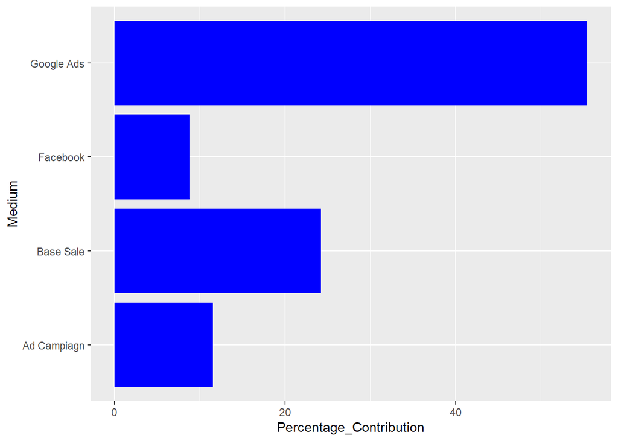

```r
Base_Sale = linear_model$coefficients[1]
google_ads = linear_model$coefficients[2]*mean(data$google_ads)
facebook = linear_model$coefficients[2]*mean(data$facebook)
ad_campaign = linear_model$coefficients[2]*mean(data$ad_campaign)

df_cc = data.frame(Medium = c("Base Sale","Google Ads","Facebook","Ad Campiagn"),Contribution = c(Base_Sale,google_ads,facebook,ad_campaign))
df_cc$Percentage_Contribution = round(df_cc$Contribution*100/sum(df_cc$Contribution),2)

ggplot(df_cc,aes(y=Percentage_Contribution,x=Medium))+geom_bar(stat='identity',fill = 'blue')+coord_flip()
```

## Price elasticity

Calculating the effectiveness or elasticity of each medium which is the percentage change in sales volume with a unit change in the spend.

```r
df_cc$Elasticity = df_cc$Contribution/mean(data$sales)
df_cc2 = df_cc
df_cc2 = df_cc2[df_cc2$Medium != 'Base Sale',c("Medium","Elasticity")]
print(df_cc2)
```

```
##        Medium Elasticity
## 2  Google Ads 0.47989644
## 3    Facebook 0.07592574
## 4 Ad Campiagn 0.09971781
```